- Contact

# case_study_2

Girish Jha

2023-04-20

```r
options(knitr.duplicate.label = "allow")
```

# Case Study: How Can a Wellness Technology Company Play It Smart?

## Capstone Project for Google Data Anaytics Professional Certificate

Working as a junior data analyst with the marketing analyst team at Bellabeat, a high-tech producer of products for women’s health. Bellabeat is a prosperous small business with the potential to grow and dominate the global market for smart devices. Bellabeat’s cofounder and chief creative officer, Urka Sren, thinks that studying fitness data from smart devices could help the business find new development prospects. I’ve been requested to concentrate on one of Bellabeat’s products and examine data from smart devices to learn more about how users are interacting with their smart gadgets. Urka Sren is certain that an examination of non-Bellebeat customer data, like as usage information from FitBit fitness trackers, will offer new prospects.

#### Business Task:

Analyze FitBit fitness tracker data to see how users interact with the FitBit app and identify trends for Bellabeat’s marketing plan.

## *Ask*

First, we must determine who are our principal stakeholders. We have the following stakeholders in this situation:

- **Urška Sršen**: Bellabeat’s co-founder and Chief Creative Officer
- **Sando Mur**: Mathematician and Bellabeat’s co-founder; key member of the Bellabeat executive team
- **Bellabeat marketing analytics team**: A team of data analysts responsible for collecting, analyzing, and reporting data that helps guide Bellabeat’s marketing strategy.

#### Business Objectives:

1. What are some trends in smart device usage?
2. How could these trends apply to Bellabeat customers?
3. How could these trends help influence Bellabeat marketing strategy?

## *Prepare*

Sršen encouraged me to use openly available data that examines the daily routines of smart device users. She directs me to the following data set:

- *FitBit Fitness Tracker Data*(CC0: Public Domain, dataset made available through Mobius): This Kaggle data set contains personal fitness tracker from thirty fitbit users. Thirty eligible Fitbit users consented to the submission of personal tracker data, including minute-level output for physical activity, heart rate, and sleep monitoring. It includes information about daily activity, steps, and heart rate that can be used to explore users’ habits.

In the Prepare phase, we identify the data being used and its limitations.

- Data was gathered in 2016, seven years ago. Since then, users’ routines for everyday activity, eating, exercising, and sleeping may have changed. Info might not be current or pertinent.

### A good data source should be ROCCC

- **Reliable**: Low - Not reliable as it only has 30 respondents.
- **Orignal**: Low - 3<sup>rd</sup> Party Provider (Amazon Mechanical Turk).
- **Comprehensive**: Med - Parameters match most of the Bellabeat product’s parameters.
- **Current**: Low - Data is 7 year old (2016) and may not be relevant now.
- **Cited**: Low - Data is collected fom 3<sup>rd</sup> party, hence unknown.

Overall, the dataset is regarded as having low quality data, and it is not advised to base business suggestions on it.

## *Process*

In this stage, we will clean the data and make sure it is accurate, pertinent, complete, and error-free.

- We want to check for missing values
- Transform the data so that we can perform analysis on it

I have cleaned, transformed, analysed, and visualised data using **RStudio**.

Firstly, we need to install the necessary packages

```r
install.packages("tidyverse")
		install.packages("lubridate")
		install.packages("ggplot2")
		install.packages("dplyr")
		install.packages("skimr")
		install.packages("janitor")
		install.packages("plotrix")
		install.packages("sqldf")
```

Now, we need to load these packages :

```r
library(tidyverse)
```

[output not shown]

```r
library(lubridate)
		library(ggplot2)
		library(dplyr)
		library(skimr)
		library(janitor)
library(plotrix)
		library(sqldf)
```

Now let’s read the data:

```r
daily_activity <- read.csv("Fitabase Data 4.12.16-5.12.16/dailyActivity_merged.csv")
		sleep_per_day <- read.csv("Fitabase Data 4.12.16-5.12.16/sleepDay_merged.csv")
		weight_log_info <- read.csv("Fitabase Data 4.12.16-5.12.16/weightLogInfo_merged.csv")
```

Now, we should take a look at these data to check for data structure and other things, using some R functions:

#### daily_activity

```r
str(daily_activity)
```

```
## 'data.frame':    940 obs. of  15 variables:
		##  $ Id                      : num  1.5e+09 1.5e+09 1.5e+09 1.5e+09 1.5e+09 ...
		##  $ ActivityDate            : chr  "4/12/2016" "4/13/2016" "4/14/2016" "4/15/2016" ...
		##  $ TotalSteps              : int  13162 10735 10460 9762 12669 9705 13019 15506 10544 9819 ...
		##  $ TotalDistance           : num  8.5 6.97 6.74 6.28 8.16 ...
		##  $ TrackerDistance         : num  8.5 6.97 6.74 6.28 8.16 ...
		##  $ LoggedActivitiesDistance: num  0 0 0 0 0 0 0 0 0 0 ...
		##  $ VeryActiveDistance      : num  1.88 1.57 2.44 2.14 2.71 ...
		##  $ ModeratelyActiveDistance: num  0.55 0.69 0.4 1.26 0.41 ...
		##  $ LightActiveDistance     : num  6.06 4.71 3.91 2.83 5.04 ...
		##  $ SedentaryActiveDistance : num  0 0 0 0 0 0 0 0 0 0 ...
		##  $ VeryActiveMinutes       : int  25 21 30 29 36 38 42 50 28 19 ...
		##  $ FairlyActiveMinutes     : int  13 19 11 34 10 20 16 31 12 8 ...
		##  $ LightlyActiveMinutes    : int  328 217 181 209 221 164 233 264 205 211 ...
		##  $ SedentaryMinutes        : int  728 776 1218 726 773 539 1149 775 818 838 ...
		##  $ Calories                : int  1985 1797 1776 1745 1863 1728 1921 2035 1786 1775 ...
```

```r
skim(daily_activity)
```

Data summary

| Name | daily_activity |
| --- | --- |
| Number of rows | 940 |
| Number of columns | 15 |
| _______________________ |  |
| Column type frequency: |  |
| character | 1 |
| numeric | 14 |
| ________________________ |  |
| Group variables | None |

**Variable type: character**

| skim_variable | n_missing | complete_rate | min | max | empty | n_unique | whitespace |
| --- | --- | --- | --- | --- | --- | --- | --- |
| ActivityDate | 0 | 1 | 8 | 9 | 0 | 31 | 0 |

**Variable type: numeric**

| skim_variable | n_missing | complete_rate | mean | sd | p0 | p25 | p50 | p75 | p100 | hist |
| --- | --- | --- | --- | --- | --- | --- | --- | --- | --- | --- |
| Id | 0 | 1 | 4.855407e+09 | 2.424805e+09 | 1503960366 | 2.320127e+09 | 4.445115e+09 | 6.962181e+09 | 8.877689e+09 | ▇▅▃▅▅ |
| TotalSteps | 0 | 1 | 7.637910e+03 | 5.087150e+03 | 0 | 3.789750e+03 | 7.405500e+03 | 1.072700e+04 | 3.601900e+04 | ▇▇▁▁▁ |
| TotalDistance | 0 | 1 | 5.490000e+00 | 3.920000e+00 | 0 | 2.620000e+00 | 5.240000e+00 | 7.710000e+00 | 2.803000e+01 | ▇▆▁▁▁ |
| TrackerDistance | 0 | 1 | 5.480000e+00 | 3.910000e+00 | 0 | 2.620000e+00 | 5.240000e+00 | 7.710000e+00 | 2.803000e+01 | ▇▆▁▁▁ |
| LoggedActivitiesDistance | 0 | 1 | 1.100000e-01 | 6.200000e-01 | 0 | 0.000000e+00 | 0.000000e+00 | 0.000000e+00 | 4.940000e+00 | ▇▁▁▁▁ |
| VeryActiveDistance | 0 | 1 | 1.500000e+00 | 2.660000e+00 | 0 | 0.000000e+00 | 2.100000e-01 | 2.050000e+00 | 2.192000e+01 | ▇▁▁▁▁ |
| ModeratelyActiveDistance | 0 | 1 | 5.700000e-01 | 8.800000e-01 | 0 | 0.000000e+00 | 2.400000e-01 | 8.000000e-01 | 6.480000e+00 | ▇▁▁▁▁ |
| LightActiveDistance | 0 | 1 | 3.340000e+00 | 2.040000e+00 | 0 | 1.950000e+00 | 3.360000e+00 | 4.780000e+00 | 1.071000e+01 | ▆▇▆▁▁ |
| SedentaryActiveDistance | 0 | 1 | 0.000000e+00 | 1.000000e-02 | 0 | 0.000000e+00 | 0.000000e+00 | 0.000000e+00 | 1.100000e-01 | ▇▁▁▁▁ |
| VeryActiveMinutes | 0 | 1 | 2.116000e+01 | 3.284000e+01 | 0 | 0.000000e+00 | 4.000000e+00 | 3.200000e+01 | 2.100000e+02 | ▇▁▁▁▁ |
| FairlyActiveMinutes | 0 | 1 | 1.356000e+01 | 1.999000e+01 | 0 | 0.000000e+00 | 6.000000e+00 | 1.900000e+01 | 1.430000e+02 | ▇▁▁▁▁ |
| LightlyActiveMinutes | 0 | 1 | 1.928100e+02 | 1.091700e+02 | 0 | 1.270000e+02 | 1.990000e+02 | 2.640000e+02 | 5.180000e+02 | ▅▇▇▃▁ |
| SedentaryMinutes | 0 | 1 | 9.912100e+02 | 3.012700e+02 | 0 | 7.297500e+02 | 1.057500e+03 | 1.229500e+03 | 1.440000e+03 | ▁▁▇▅▇ |
| Calories | 0 | 1 | 2.303610e+03 | 7.181700e+02 | 0 | 1.828500e+03 | 2.134000e+03 | 2.793250e+03 | 4.900000e+03 | ▁▆▇▃▁ |

```r
head(daily_activity)
```

```
##           Id ActivityDate TotalSteps TotalDistance TrackerDistance
		## 1 1503960366    4/12/2016      13162          8.50            8.50
		## 2 1503960366    4/13/2016      10735          6.97            6.97
		## 3 1503960366    4/14/2016      10460          6.74            6.74
		## 4 1503960366    4/15/2016       9762          6.28            6.28
		## 5 1503960366    4/16/2016      12669          8.16            8.16
		## 6 1503960366    4/17/2016       9705          6.48            6.48
		##   LoggedActivitiesDistance VeryActiveDistance ModeratelyActiveDistance
		## 1                        0               1.88                     0.55
		## 2                        0               1.57                     0.69
		## 3                        0               2.44                     0.40
		## 4                        0               2.14                     1.26
		## 5                        0               2.71                     0.41
		## 6                        0               3.19                     0.78
		##   LightActiveDistance SedentaryActiveDistance VeryActiveMinutes
		## 1                6.06                       0                25
		## 2                4.71                       0                21
		## 3                3.91                       0                30
		## 4                2.83                       0                29
		## 5                5.04                       0                36
		## 6                2.51                       0                38
		##   FairlyActiveMinutes LightlyActiveMinutes SedentaryMinutes Calories
		## 1                  13                  328              728     1985
		## 2                  19                  217              776     1797
		## 3                  11                  181             1218     1776
		## 4                  34                  209              726     1745
		## 5                  10                  221              773     1863
		## 6                  20                  164              539     1728
```

#### sleep_per_day

```r
str(sleep_per_day)
```

```
## 'data.frame':    413 obs. of  5 variables:
		##  $ Id                : num  1.5e+09 1.5e+09 1.5e+09 1.5e+09 1.5e+09 ...
		##  $ SleepDay          : chr  "4/12/2016 12:00:00 AM" "4/13/2016 12:00:00 AM" "4/15/2016 12:00:00 AM" "4/16/2016 12:00:00 AM" ...
		##  $ TotalSleepRecords : int  1 2 1 2 1 1 1 1 1 1 ...
		##  $ TotalMinutesAsleep: int  327 384 412 340 700 304 360 325 361 430 ...
		##  $ TotalTimeInBed    : int  346 407 442 367 712 320 377 364 384 449 ...
```

```r
skim(sleep_per_day)
```

Data summary

| Name | sleep_per_day |
| --- | --- |
| Number of rows | 413 |
| Number of columns | 5 |
| _______________________ |  |
| Column type frequency: |  |
| character | 1 |
| numeric | 4 |
| ________________________ |  |
| Group variables | None |

**Variable type: character**

| skim_variable | n_missing | complete_rate | min | max | empty | n_unique | whitespace |
| --- | --- | --- | --- | --- | --- | --- | --- |
| SleepDay | 0 | 1 | 20 | 21 | 0 | 31 | 0 |

**Variable type: numeric**

| skim_variable | n_missing | complete_rate | mean | sd | p0 | p25 | p50 | p75 | p100 | hist |
| --- | --- | --- | --- | --- | --- | --- | --- | --- | --- | --- |
| Id | 0 | 1 | 5.000979e+09 | 2.06036e+09 | 1503960366 | 3977333714 | 4702921684 | 6962181067 | 8792009665 | ▆▆▇▅▃ |
| TotalSleepRecords | 0 | 1 | 1.120000e+00 | 3.50000e-01 | 1 | 1 | 1 | 1 | 3 | ▇▁▁▁▁ |
| TotalMinutesAsleep | 0 | 1 | 4.194700e+02 | 1.18340e+02 | 58 | 361 | 433 | 490 | 796 | ▁▂▇▃▁ |
| TotalTimeInBed | 0 | 1 | 4.586400e+02 | 1.27100e+02 | 61 | 403 | 463 | 526 | 961 | ▁▃▇▁▁ |

```r
head(sleep_per_day)
```

```
##           Id              SleepDay TotalSleepRecords TotalMinutesAsleep
		## 1 1503960366 4/12/2016 12:00:00 AM                 1                327
		## 2 1503960366 4/13/2016 12:00:00 AM                 2                384
		## 3 1503960366 4/15/2016 12:00:00 AM                 1                412
		## 4 1503960366 4/16/2016 12:00:00 AM                 2                340
		## 5 1503960366 4/17/2016 12:00:00 AM                 1                700
		## 6 1503960366 4/19/2016 12:00:00 AM                 1                304
		##   TotalTimeInBed
		## 1            346
		## 2            407
		## 3            442
		## 4            367
		## 5            712
		## 6            320
```

#### weight_log_info

```r
str(weight_log_info)
```

```
## 'data.frame':    67 obs. of  8 variables:
		##  $ Id            : num  1.50e+09 1.50e+09 1.93e+09 2.87e+09 2.87e+09 ...
		##  $ Date          : chr  "5/2/2016 11:59:59 PM" "5/3/2016 11:59:59 PM" "4/13/2016 1:08:52 AM" "4/21/2016 11:59:59 PM" ...
		##  $ WeightKg      : num  52.6 52.6 133.5 56.7 57.3 ...
		##  $ WeightPounds  : num  116 116 294 125 126 ...
		##  $ Fat           : int  22 NA NA NA NA 25 NA NA NA NA ...
		##  $ BMI           : num  22.6 22.6 47.5 21.5 21.7 ...
		##  $ IsManualReport: chr  "True" "True" "False" "True" ...
		##  $ LogId         : num  1.46e+12 1.46e+12 1.46e+12 1.46e+12 1.46e+12 ...
```

```r
skim(weight_log_info)
```

Data summary

| Name | weight_log_info |
| --- | --- |
| Number of rows | 67 |
| Number of columns | 8 |
| _______________________ |  |
| Column type frequency: |  |
| character | 2 |
| numeric | 6 |
| ________________________ |  |
| Group variables | None |

**Variable type: character**

| skim_variable | n_missing | complete_rate | min | max | empty | n_unique | whitespace |
| --- | --- | --- | --- | --- | --- | --- | --- |
| Date | 0 | 1 | 19 | 21 | 0 | 56 | 0 |
| IsManualReport | 0 | 1 | 4 | 5 | 0 | 2 | 0 |

**Variable type: numeric**

| skim_variable | n_missing | complete_rate | mean | sd | p0 | p25 | p50 | p75 | p100 | hist |
| --- | --- | --- | --- | --- | --- | --- | --- | --- | --- | --- |
| Id | 0 | 1.00 | 7.009282e+09 | 1.950322e+09 | 1.503960e+09 | 6.962181e+09 | 6.962181e+09 | 8.877689e+09 | 8.877689e+09 | ▁▁▂▇▆ |
| WeightKg | 0 | 1.00 | 7.204000e+01 | 1.392000e+01 | 5.260000e+01 | 6.140000e+01 | 6.250000e+01 | 8.505000e+01 | 1.335000e+02 | ▇▃▃▁▁ |
| WeightPounds | 0 | 1.00 | 1.588100e+02 | 3.070000e+01 | 1.159600e+02 | 1.353600e+02 | 1.377900e+02 | 1.875000e+02 | 2.943200e+02 | ▇▃▃▁▁ |
| Fat | 65 | 0.03 | 2.350000e+01 | 2.120000e+00 | 2.200000e+01 | 2.275000e+01 | 2.350000e+01 | 2.425000e+01 | 2.500000e+01 | ▇▁▁▁▇ |
| BMI | 0 | 1.00 | 2.519000e+01 | 3.070000e+00 | 2.145000e+01 | 2.396000e+01 | 2.439000e+01 | 2.556000e+01 | 4.754000e+01 | ▇▁▁▁▁ |
| LogId | 0 | 1.00 | 1.461772e+12 | 7.829948e+08 | 1.460444e+12 | 1.461079e+12 | 1.461802e+12 | 1.462375e+12 | 1.463098e+12 | ▇▇▆▇▇ |

```r
head(weight_log_info)
```

```
##           Id                  Date WeightKg WeightPounds Fat   BMI
		## 1 1503960366  5/2/2016 11:59:59 PM     52.6     115.9631  22 22.65
		## 2 1503960366  5/3/2016 11:59:59 PM     52.6     115.9631  NA 22.65
		## 3 1927972279  4/13/2016 1:08:52 AM    133.5     294.3171  NA 47.54
		## 4 2873212765 4/21/2016 11:59:59 PM     56.7     125.0021  NA 21.45
		## 5 2873212765 5/12/2016 11:59:59 PM     57.3     126.3249  NA 21.69
		## 6 4319703577 4/17/2016 11:59:59 PM     72.4     159.6147  25 27.45
		##   IsManualReport        LogId
		## 1           True 1.462234e+12
		## 2           True 1.462320e+12
		## 3          False 1.460510e+12
		## 4           True 1.461283e+12
		## 5           True 1.463098e+12
		## 6           True 1.460938e+12
```

After executing above command we found:

- Number of observations and columns
- Number of null and non-null values
- DataType of each column

We can see that there are 940 observation in daily_activity, 413 in sleep_per_day and 67 in weight_log_info. Null value is present at only one column(Fat in weight_log_info), and also the completion rate of that column is *0.03*, so we can remove the column if needed, as it doesn’t provide any information.

So there is no other requirement to clean the data. But the ActivityDate column in *daily_activity* is in character format, so we need to to transform it into datetime64 type. I’ve also created month and day_of_week as we will be needing them for our analysis.

```r
daily_activity$Rec_Date <- as.Date(daily_activity$ActivityDate,"%m/%d/%y")
		daily_activity$month <- format(daily_activity$Rec_Date,"%B")
		daily_activity$day_of_week <- format(daily_activity$Rec_Date,"%A")
```

We should see also check the count of unique IDs to confirm data has 30 IDs as claimed by the survey.

```r
n_distinct(daily_activity$Id)
```

```
## [1] 33
```

We can see that there are 33 unique IDs, some users may have created additional IDs during the survey period.

This concludes our processing phase.

## *Analyze*

Now, we should try to summarize the data and gain some insights in the process.

#### daily_activity statistical summary

```r
daily_activity %>%
		  select(TotalSteps,TotalDistance,SedentaryMinutes,VeryActiveMinutes) %>%
		  summary()
```

```
##    TotalSteps    TotalDistance    SedentaryMinutes VeryActiveMinutes
		##  Min.   :    0   Min.   : 0.000   Min.   :   0.0   Min.   :  0.00
		##  1st Qu.: 3790   1st Qu.: 2.620   1st Qu.: 729.8   1st Qu.:  0.00
		##  Median : 7406   Median : 5.245   Median :1057.5   Median :  4.00
		##  Mean   : 7638   Mean   : 5.490   Mean   : 991.2   Mean   : 21.16
		##  3rd Qu.:10727   3rd Qu.: 7.713   3rd Qu.:1229.5   3rd Qu.: 32.00
		##  Max.   :36019   Max.   :28.030   Max.   :1440.0   Max.   :210.00
```

#### weight_log_info statistical summary

```r
weight_log_info %>%
		  select(WeightKg,BMI) %>%
		  summary()
```

```
##     WeightKg           BMI
		##  Min.   : 52.60   Min.   :21.45
		##  1st Qu.: 61.40   1st Qu.:23.96
		##  Median : 62.50   Median :24.39
		##  Mean   : 72.04   Mean   :25.19
		##  3rd Qu.: 85.05   3rd Qu.:25.56
		##  Max.   :133.50   Max.   :47.54
```

#### sleep_per_day summary

```r
Avg_minutes_asleep <- sqldf("SELECT SUM(TotalSleepRecords),SUM(TotalMinutesAsleep)/SUM(TotalSleepRecords) as avg_sleeptime
									FROM sleep_per_day")
		Avg_minutes_asleep
```

```
##   SUM(TotalSleepRecords) avg_sleeptime
		## 1                    462           374
```

```r
Avg_TimeInBed <- sqldf("SELECT SUM(TotalTimeInBed)/SUM(TotalSleepRecords) as avg_timeInBed
							   FROM sleep_per_day")

		Avg_TimeInBed
```

```
##   avg_timeInBed
		## 1           409
```

## *Share*

In this phase, we will create some visualizations based on our analysis and our objectives.

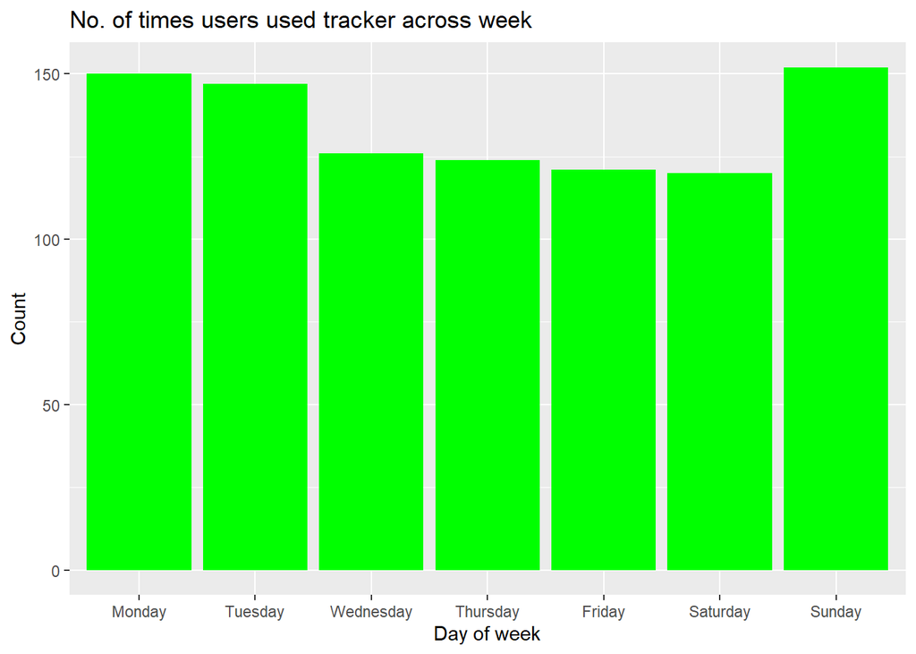

```r
daily_activity$day_of_week <- ordered(daily_activity$day_of_week,levels=c("Monday","Tuesday","Wednesday","Thursday","Friday","Saturday","Sunday"))

		ggplot(data=daily_activity) + geom_bar(mapping = aes(x=day_of_week),fill="green") +
		  labs(x="Day of week",y="Count",title="No. of times users used tracker across week")
```

```r
mean_steps <- mean(daily_activity$TotalSteps)
		mean_steps
```

```
## [1] 7637.911
```

```r
mean_calories <- mean(daily_activity$Calories)
		mean_calories
```

```
## [1] 2303.61
```

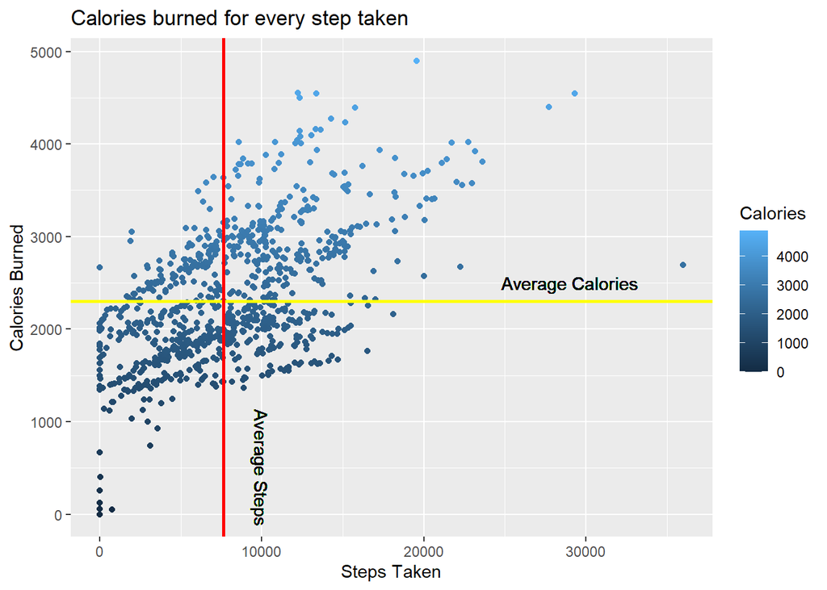

```r
ggplot(data=daily_activity) + geom_point(mapping=aes(x=TotalSteps, y=Calories, color=Calories)) +
		  geom_hline(mapping = aes(yintercept=mean_calories),color="yellow",lwd=1.0) +
		  geom_vline(mapping = aes(xintercept=mean_steps),color="red",lwd=1.0) +
		  geom_text(mapping = aes(x=10000,y=500,label="Average Steps",srt=-90)) +
		  geom_text(mapping = aes(x=29000,y=2500,label="Average Calories")) +
		  labs(x="Steps Taken",y="Calories Burned",title = "Calories burned for every step taken")
```

- With a few outliers at the bottom and top of the scatter plot, it is a positive association.
- The figure makes it evident that the intensity of calories burnt rises with the quantity of steps done.

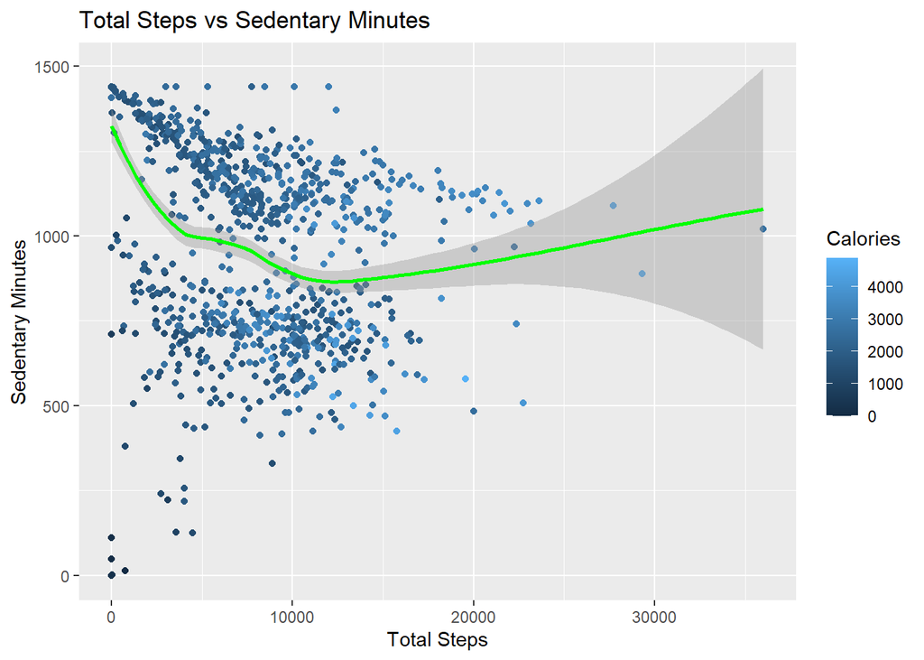

```r
ggplot(data=daily_activity, aes(x=TotalSteps, y=SedentaryMinutes, color = Calories)) + geom_point() +
		geom_smooth(method = "loess",color="green") +
		labs(x="Total Steps",y="Sedentary Minutes",title="Total Steps vs Sedentary Minutes")
```

I had anticipated that the number of steps and the number of sedentary minutes would be completely opposite.

- The relationship between them is inverse at first when there are fewer than 10,000 steps done, but when the number of steps rises above 10,000, there is little change in the relationship.
- I was somewhat aback by how slightly favourable the relationship between steps and sedentary minutes became beyond 15000 steps.

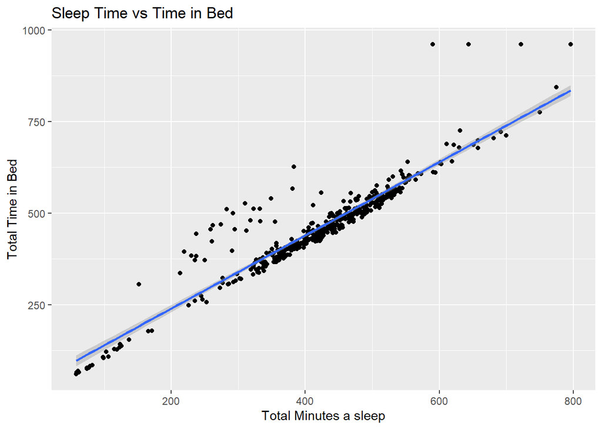

```r
ggplot(data=sleep_per_day, aes(x=TotalMinutesAsleep, y=TotalTimeInBed)) + geom_point() + stat_smooth(method = lm) +
		  labs(x="Total Minutes a sleep", y="Total Time in Bed", title = "Sleep Time vs Time in Bed")
```

- As we can see, TotalMinutesAsleep and TotalTimeInBed have a high positive association, however the middle and top of the plot contain several outliers in the data.
- Those who spent a lot of time in bed but didn’t sleep are the outliers. There may be a variety of causes behind that.

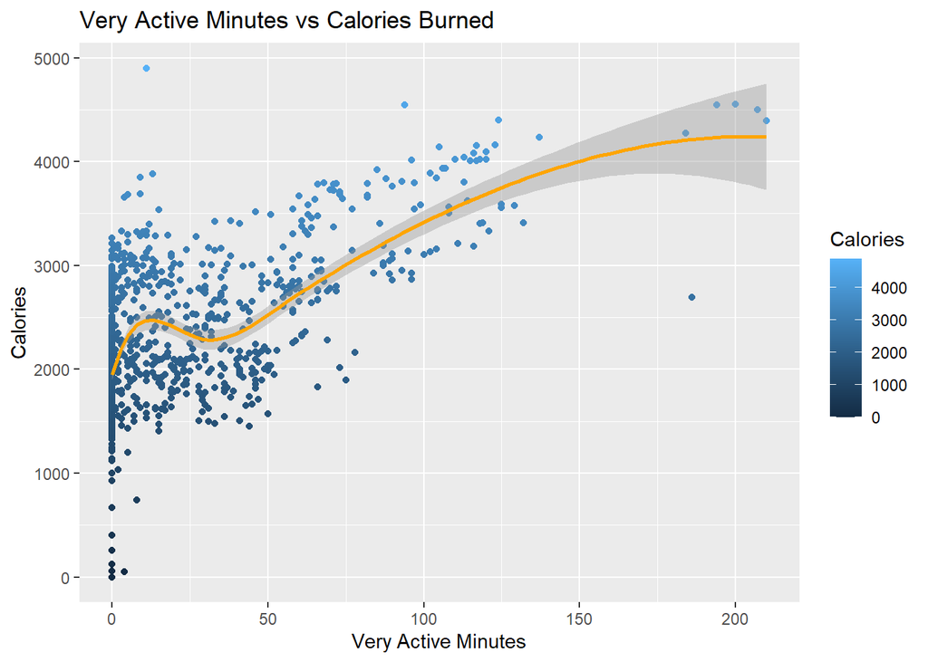

```r
ggplot(data=daily_activity,aes(x = VeryActiveMinutes, y = Calories, color = Calories)) + geom_point() +
		  geom_smooth(method = "loess",color="orange") +
		  labs(x="Very Active Minutes",y="Calories",title = "Very Active Minutes vs Calories Burned")
```

As we can see, there is a strong correlation between very active minutes and calories burned, with some outliers at the bottom and top left of the image.

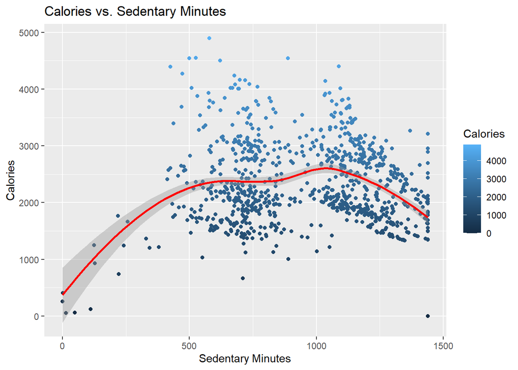

```r
ggplot(data=daily_activity,aes(x=SedentaryMinutes,y=Calories,color=Calories)) + geom_point() +
		geom_smooth(method="loess",color="red") +
		labs(y="Calories", x="Sedentary Minutes", title="Calories vs. Sedentary Minutes")
```

I had anticipated a completely inverse relationship between the amount of time spent sitting and the number of calories burned.

- The data up to 1000 sedentary minutes demonstrates a positive association.
- The relationship is inverse after 1000 sedentary minutes, as I had anticipated.

Now, we calculate sum of each minute columns indivually from daily activity data and try to plot a pie chart to visualize better.

```r
activity_min <- sqldf("SELECT SUM(VeryActiveMinutes),SUM(FairlyActiveMinutes),
			  SUM(LightlyActiveMinutes),SUM(SedentaryMinutes)
			  FROM daily_activity")
		activity_min
```

```
##   SUM(VeryActiveMinutes) SUM(FairlyActiveMinutes) SUM(LightlyActiveMinutes)
		## 1                  19895                    12751                    181244
		##   SUM(SedentaryMinutes)
		## 1                931738
```

```r
x <- c(19895,12751,181244,931738)
		x
```

```
## [1]  19895  12751 181244 931738
```

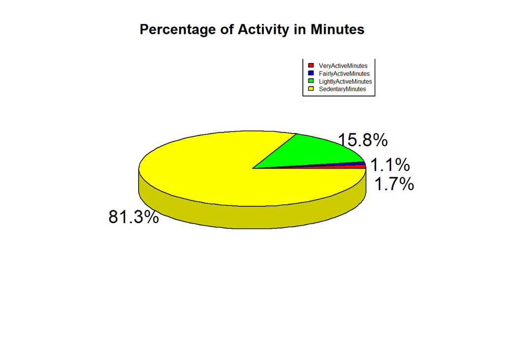

```r
piepercent <- round(100*x / sum(x), 1)
		colors = c("red","blue","green","yellow")
		pie3D(x,labels = paste0(piepercent,"%"),col=colors,main = "Percentage of Activity in Minutes")
		legend("topright",c("VeryActiveMinutes","FairlyActiveMinutes","LightlyActiveMinutes","SedentaryMinutes"),cex=0.5,fill = colors)
```

As may be seen,

- Sedentary minutes account for 81.3% of all minutes, which is a significantly high percentage compared to all other minutes. This shows that people tend to be inactive for longer periods of time.
- When compared to other activities, the percentage of highly active and fairly active minutes is very low (1.7% and 1.1%, respectively).

Now, we will calculate sum of different distance values from daily activity data:

```r
activity_dist <- sqldf("SELECT SUM(ModeratelyActiveDistance),SUM(LightActiveDistance),
			  SUM(VeryActiveDistance),SUM(SedentaryActiveDistance)
			  FROM daily_activity")
		activity_dist
```

```
##   SUM(ModeratelyActiveDistance) SUM(LightActiveDistance)
		## 1                        533.49                  3140.37
		##   SUM(VeryActiveDistance) SUM(SedentaryActiveDistance)
		## 1                 1412.52                         1.51
```

```r
y <- c(533.49,3140.37,1412.52)
		y
```

```
## [1]  533.49 3140.37 1412.52
```

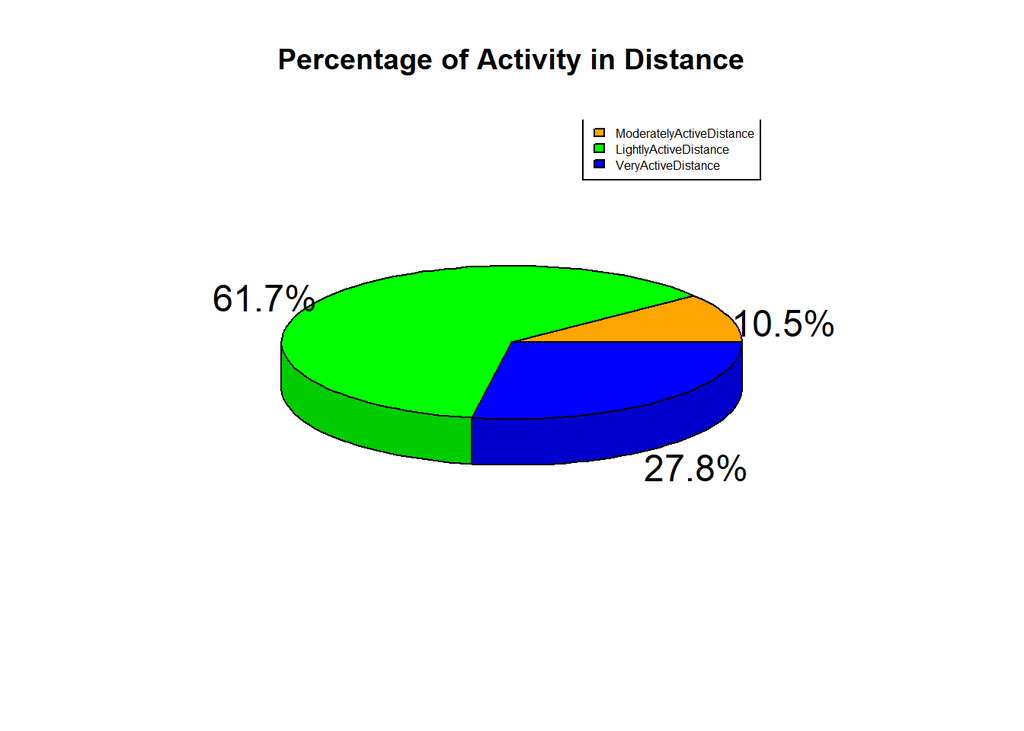

```r
piepercent <- round(100*y / sum(y), 1)
		colors = c("orange","green","blue")
		pie3D(y,labels = paste0(piepercent,"%"),col=colors,main = "Percentage of Activity in Distance")
		legend("topright",c("ModeratelyActiveDistance","LightlyActiveDistance","VeryActiveDistance"),cex=0.5,fill = colors)
```

As we can see,

- The percentage of lightly active distance is highest with 61.7% and that of moderately active distance is 10.5%.
- The percentage of very active distance is 27.8% which is good, but it can be increased further so that people can achieve there fitness goals.

Now, we will calculate the count of people with over weight: The BMI for healthy person is between 18.5 and 24.9 and the persons who’s BMI is above 24.9 are considered to be overweight.(source:CDC)

```r
count_overweight <- sqldf("SELECT COUNT(DISTINCT(Id))
								  FROM weight_log_info
								  WHERE BMI > 24.9")
		count_overweight
```

```
##   COUNT(DISTINCT(Id))
		## 1                   5
```

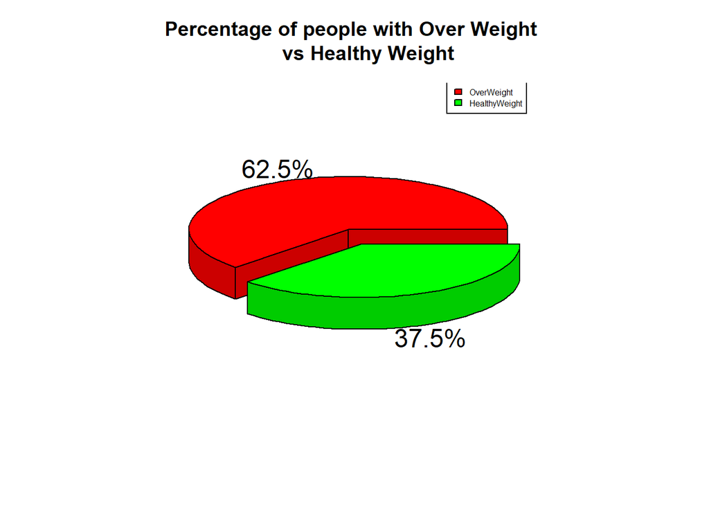

```r
z <- c(5,3)
		piepercent <- round(100*z / sum(z),1)
		colors = c("red","green")
		pie3D(z,labels=paste0(piepercent,"%"),explode=0.1,col=colors,radius=1,main="Percentage of people with Over Weight
			 vs Healthy Weight")
		legend("topright",c("OverWeight","HealthyWeight"),cex=0.5,fill=colors)
```

Although we have fewer records, we can still see

- 62.5% of people are overweight, which is a higher percentage than the 37.5% of persons who are in a healthy weight range. So, there is a great chance to raise the proportion of people who are a healthy weight.

## *Act*

The analysis’s intended outcome was achieved because the FitBit data provided us with a wealth of insightful information that will enable us to make informed decisions. Both businesses produce goods of a similar nature. So, Bellabeat clients can also benefit from the general trends in health and fitness.